# DS4_Sentiment_Analysis_Céline_Dion_vs_Madonna

Agnes Kollaine Stark

5/4/2020

My project is going to be a sentiment analysis of Céline Dion’s album of 1999 : “All the Way… a Decade of Song” versus Madonna’s album of 1998: “Ray of Light”.

My hypothesis is that Céline Dion’s songs are more positive than Madonna’s.

**Data engineering, exploration**

```r
client_id <- 'Your_ID_here'
client_secret <- 'Your_Password_here'
client_access_token <- 'Your_token_here'
GENIUS_API_TOKEN <- 'Your_token_here'
```

Getting the two albums in one dataframe

```r
artist_albums <- tribble(
  ~artist, ~album,
  "Céline Dion", "All the Way... A Decade of Song",
  "Madonna", "Ray of Light"
)

df <- artist_albums %>%
  add_genius(artist, album)

# unnesting so that each word is a row
unnested_df <- df %>%
  unnest_tokens(word, lyric)

# removing stop words
df2 <- unnested_df %>%
  anti_join(custom_stop_words)

# writing to csv in case I lose connection at further steps
write_csv(df2,"Céline_Madonna_data.csv" )
```

```r
df2 <- read_csv("Céline_Madonna_data.csv")
```

```r
# separate df for Céline D
celine <- filter(df2,artist == "Céline Dion")
```

```r
# separate df for Madonna
madonna <- filter(df2, artist == "Madonna")
madonna = madonna[-1,]
```

First step of the analysis :

Count most common words as a whole

```r
df3 <- df2 %>%
  count(word, sort = TRUE)
df3
```

```
## # A tibble: 574 x 2
##    word       n
##    <chr>  <int>
##  1 love     104
##  2 heart     42
##  3 baby      28
##  4 feel      26
##  5 candy     22
##  6 hold      22
##  7 ran       22
##  8 coming    21
##  9 life      21
## 10 faith     20
## # ... with 564 more rows
```

Love is by far the most common word, the second place belongs to “heart” followed by “baby” .

We can also visualize these words, to see the weight and the differences better. For now we are only looking at words that are present more than 21 times.

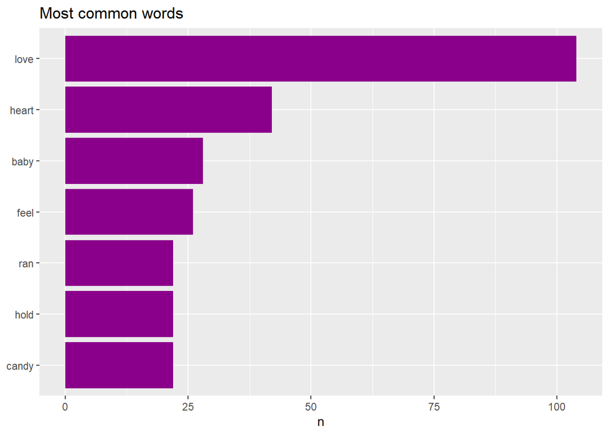

```r
df2 %>%
  count(word, sort = TRUE) %>%
  filter( n > 21) %>%
    mutate(word = reorder(word, n)) %>%
  ggplot(aes(word, n)) +
  geom_col(fill = "darkmagenta") +
  xlab(NULL) +
  coord_flip() +
  ggtitle("Most common words")
```

Looking at the individual datasets, shows us Céline Dion uses the word “love” much more often, than Madonna.

```r
celine_rank<- celine %>%
  count(word, sort = TRUE)
celine_rank
```

```
## # A tibble: 308 x 2
##    word       n
##    <chr>  <int>
##  1 love      78
##  2 baby      26
##  3 heart     25
##  4 coming    21
##  5 faith     20
##  6 yeah      16
##  7 time      14
##  8 feel      13
##  9 life      13
## 10 angel     11
## # ... with 298 more rows
```

```r
madonna_rank <- madonna %>%
  count(word, sort = TRUE)
madonna_rank
```

```
## # A tibble: 346 x 2
##    word        n
##    <chr>   <int>
##  1 love       26
##  2 candy      22
##  3 ran        22
##  4 shanti     20
##  5 heart      17
##  6 girl       16
##  7 perfume    16
##  8 hold       15
##  9 mmmmmm     15
## 10 om         15
## # ... with 336 more rows
```

**Sentiment Analysis using various lexicons**

Now let’s look at the sentiments that can be found in the two albums.

```r
#let's see what sentiments there are in the nrc lexicon

nrc_sentiments <- get_sentiments("nrc")

df_sentiments <- df2 %>%
  inner_join(nrc_sentiments)
  #count(word, sort = TRUE)
```

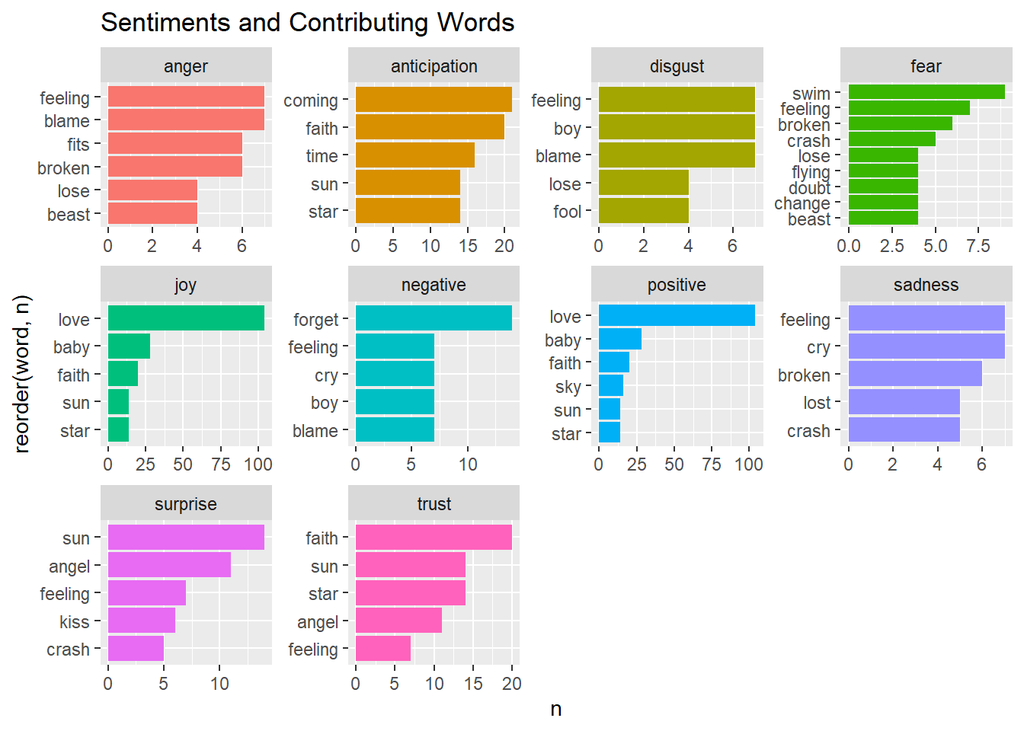

```r
df_sentiments %>%
  count(word,sentiment,sort=TRUE) %>%
group_by(sentiment)%>%top_n(n=5) %>%
ungroup() %>%
  ggplot(aes(x=reorder(word,n),y=n,fill=sentiment)) +
  geom_col(show.legend = FALSE) +
  facet_wrap(~sentiment,scales="free") +
  coord_flip() +
  ggtitle("Sentiments and Contributing Words")
```

We can see that there is a wide variety of sentiments in the combined dataset of the two albums.

What sentiments do we find if we filter to the individual artists?

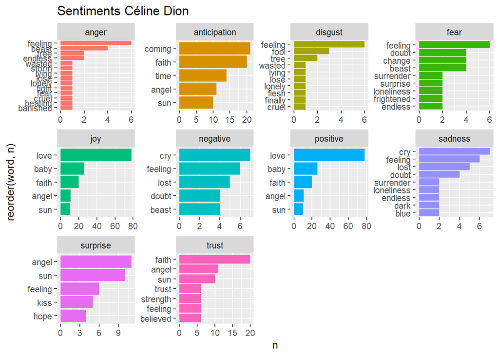

```r
celine_sentiments <- celine %>%
  inner_join(nrc_sentiments)

celine_sentiments %>%
  count(word,sentiment,sort=TRUE) %>%
group_by(sentiment)%>%top_n(n=5) %>%
ungroup() %>%
  ggplot(aes(x=reorder(word,n),y=n,fill=sentiment)) +
  geom_col(show.legend = FALSE) +
  facet_wrap(~sentiment,scales="free") +
  coord_flip() +
  ggtitle("Sentiments Céline Dion")
```

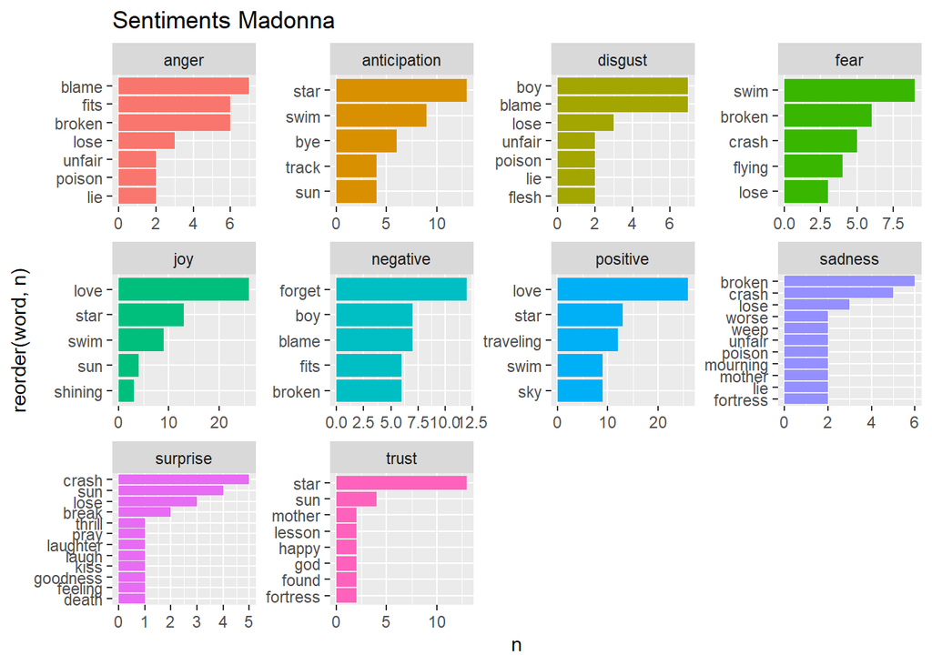

```r
madonna_sentiments <- madonna %>%
  inner_join(nrc_sentiments)

madonna_sentiments %>%
  count(word,sentiment,sort=TRUE) %>%
group_by(sentiment)%>%top_n(n=5) %>%
ungroup() %>%
  ggplot(aes(x=reorder(word,n),y=n,fill=sentiment)) +
  geom_col(show.legend = FALSE) +
  facet_wrap(~sentiment,scales="free") +
  coord_flip() +
  ggtitle("Sentiments Madonna")
```

While these graphs look nice, in our case they are not very handy, I am not able to draw any conclusions from the words used by the artists contributing to the various sentiments.

So I will now focus on positive and negative sentiments only.

```r
# select positive sentiments

nrc_pos <- get_sentiments("nrc") %>%
  filter(sentiment == "positive")

# join with df by "word"

df_pos <- df2 %>%
  inner_join(nrc_pos) %>%
  count(word, sort = TRUE) %>%
  ungroup()
```

Visualize positive words:

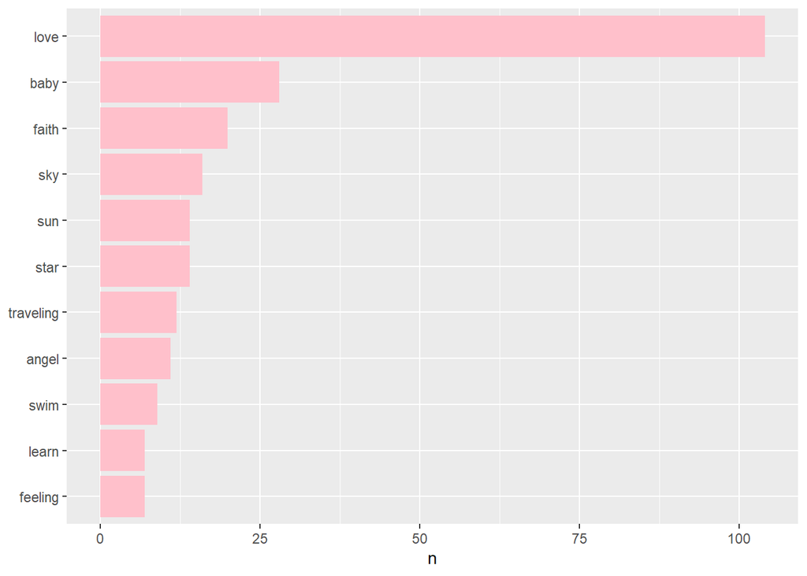

```r
df_pos %>%
  #count(word, sort = TRUE) %>%
  filter( n > 6) %>%
  mutate(word = reorder(word, n)) %>%
  ggplot(aes(word, n)) +
  geom_col(fill = "pink") +
  xlab(NULL) +
  coord_flip()
```

!If we look at the positive words, again we can see that love is the most frequent by far, followed by “baby”, “faith” and “sky”. The list of the three “sky” related words is actually quite interesting, “sky”, “sun” and “star” being in the ten most frequent.

So whom do these positive words belong to? My guess is, that love is mentioned more by Céline Dion ( which we have already seen), and faith, angel will also be mentioned more by her.

Let’s see:

```r
celine_pos <- df2 %>%
  filter( artist == "Céline Dion") %>%
  inner_join(nrc_pos) %>%
  count(word, sort = TRUE) %>%
  ungroup()

celine_pos
```

```
## # A tibble: 52 x 2
##    word         n
##    <chr>    <int>
##  1 love        78
##  2 baby        26
##  3 faith       20
##  4 angel       11
##  5 sun         10
##  6 sky          7
##  7 feeling      6
##  8 strength     6
##  9 kiss         5
## 10 shoulder     5
## # ... with 42 more rows
```

The top 5 pos words for Céline are: love, baby, faith, angel, sun.

```r
madonna_pos <- df2 %>%
  filter(artist == "Madonna") %>%
  inner_join(nrc_pos) %>%
  count(word, sort = TRUE) %>%
  ungroup()
madonna_pos
```

```
## # A tibble: 50 x 2
##    word          n
##    <chr>     <int>
##  1 love         26
##  2 star         13
##  3 traveling    12
##  4 sky           9
##  5 swim          9
##  6 learn         5
##  7 flying        4
##  8 sun           4
##  9 shining       3
## 10 baby          2
## # ... with 40 more rows
```

The top 5 pos words for Madonna are: love ( although much less frequently), star, traveling, sky… Wow! That is rather in the range of activeness.Well Madonna has always been one of those real energetic artists as far as I know.

Let’s see the negative words as well.

```r
nrc_neg <- get_sentiments("nrc") %>%
  filter(sentiment == "negative")

df_neg <- df2 %>%
  inner_join(nrc_neg) %>%
  count(word, sort = TRUE) %>%
  ungroup()
```

Top negative sentiment words visualized:

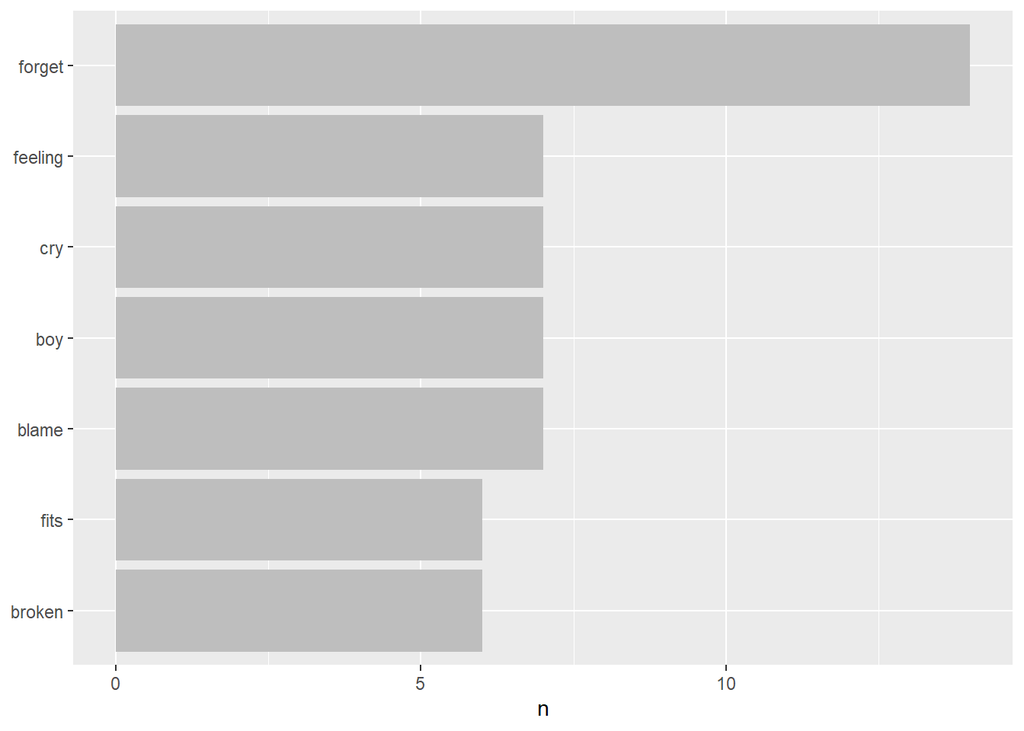

```r
df_neg %>%
  #count(word, sort = TRUE) %>%
  filter( n > 5) %>%
  mutate(word = reorder(word, n)) %>%
  ggplot(aes(word, n)) +
  geom_col(fill = "grey") +
  xlab(NULL) +
  coord_flip()
```

Interesting finding that boy is considered negative. It would be understandable had I been using bigram, to see that for example “Oh boy” is something negative. But I am unsure why “boy” as a standalone is negative.

Let’s count the most common positive and negative words using the *bing* lexicon, and look at their share.

```r
bing_word_counts <- df2 %>%
  inner_join(get_sentiments("bing")) %>%
  count(word, sentiment, sort = TRUE) %>%
  ungroup()
```

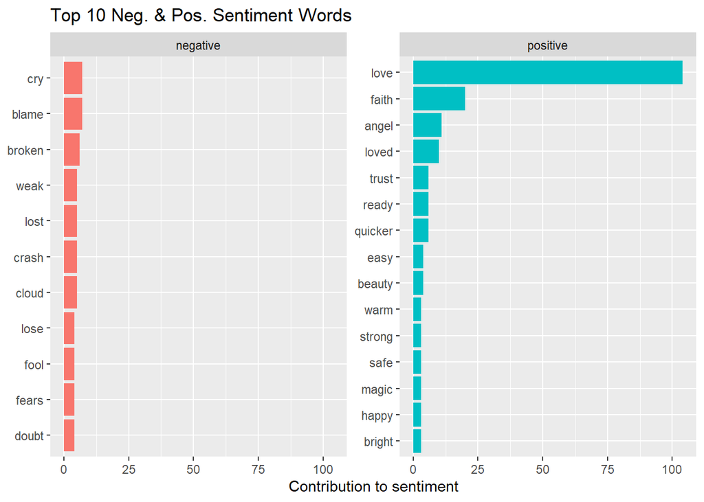

```r
bing_word_counts %>%
  group_by(sentiment) %>%
  top_n(10) %>%
  ungroup() %>%
  mutate(word = reorder(word, n)) %>%
  ggplot(aes(word, n, fill = sentiment)) +
  geom_col(show.legend = FALSE) +
  facet_wrap(~sentiment, scales = "free_y") +
  labs(y = "Contribution to sentiment",
       x = NULL) +
  coord_flip() +
  ggtitle("Top 10 Neg. & Pos. Sentiment Words")
```

The only finding we have here is that the word “love” because of its high frequency contributes a fair bit to the positive sentiment words.

We can also visualize which are the words -that are present 5 or more times - that contribute to the positive and negative sentiments.

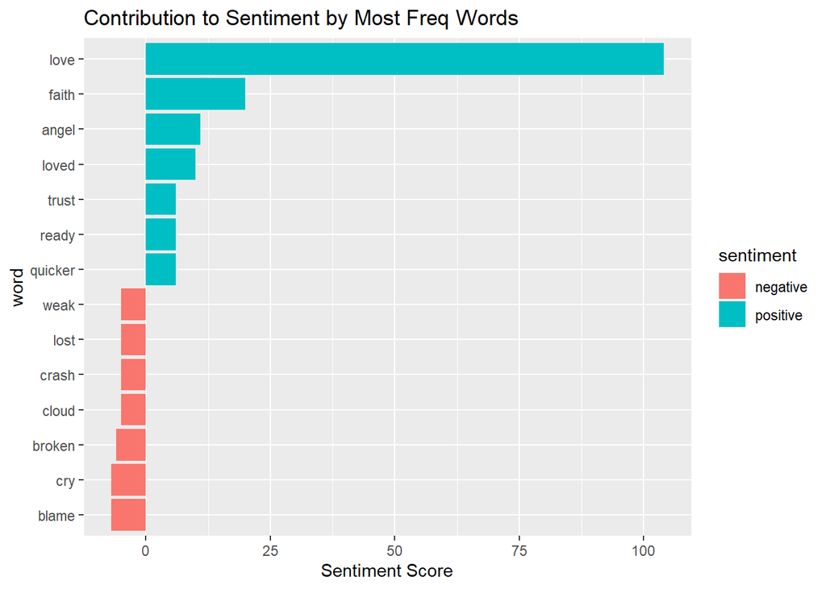

```r
bing_word_counts %>%
  filter(n >= 5) %>%
  mutate(n = ifelse(sentiment == "negative", -n , n)) %>%
  mutate(word = reorder(word, n)) %>%
  #top_n(10) %>%
  ggplot(aes(word, n, fill = sentiment)) +
  geom_col() +
  coord_flip() +
  labs(y = "Sentiment Score") +
  ggtitle("Contribution to Sentiment by Most Freq Words")
```

The bing lexicon shows us a quite string shift to the positive part with “love” leading the way, by a large bit. The negative sentiment words here are a bit more in line with my “assumptions”, such as : “broken”, “blame”, “cry”, boy is not listed here.

Visualizing individually by artist:

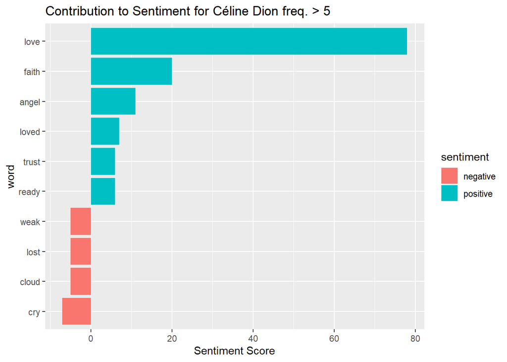

```r
bing <- get_sentiments("bing")

celine_bing <- celine %>%
  inner_join(bing) %>%
  count(word, sentiment, sort = TRUE) %>%
  ungroup()


celine_bing %>%
  filter(n >= 5) %>%
  mutate(n = ifelse(sentiment == "negative", -n , n)) %>%
  mutate(word = reorder(word, n)) %>%
  #top_n(5) %>%
  ggplot(aes(word, n, fill = sentiment)) +
  geom_col() +
  coord_flip() +
  labs(y = "Sentiment Score") +
  ggtitle("Contribution to Sentiment for Céline Dion freq. > 5")
```

And here is one of the most important points I wanted to make. Here we can see that the variety of words conttributing to positive sentiments is quite big, or at least there are definitely more words contributing to positive sentiment, than negative for Céline Dion.

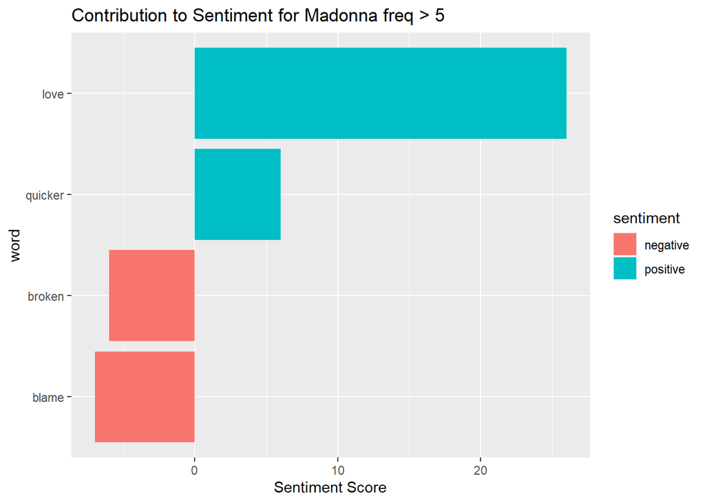

```r
madonna_bing <- madonna %>%
  inner_join(bing) %>%
  count(word, sentiment, sort = TRUE) %>%
  ungroup()

madonna_bing %>%
  filter(n > 5) %>%
  mutate(n = ifelse(sentiment == "negative", -n , n)) %>%
  mutate(word = reorder(word, n)) %>%
  #top_n(5) %>%
  ggplot(aes(word, n, fill = sentiment)) +
  geom_col() +
  coord_flip() +
  labs(y = "Sentiment Score") +
  ggtitle("Contribution to Sentiment for Madonna freq > 5")
```

For Madonna, we can see that there are only few words that appear more than 5 times that contribute to positive or negative sentiments.It seems that Madonna’s words are potentially more neutral, at least those, that are present at least 5 times in her songs.

Let’s therefore check Madonna’s words that are present at least 2 times.

```r
madonna_bing <- madonna %>%
  inner_join(bing) %>%
  count(word, sentiment, sort = TRUE) %>%
  ungroup()
```

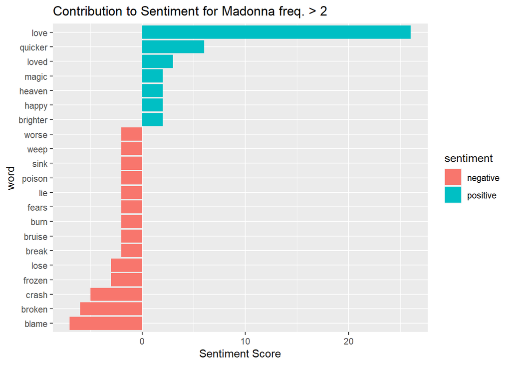

```r
madonna_bing %>%
  filter(n >= 2) %>%
  mutate(n = ifelse(sentiment == "negative", -n , n)) %>%
  mutate(word = reorder(word, n)) %>%
  ggplot(aes(word, n, fill = sentiment)) +
  geom_col() +
  coord_flip() +
  labs(y = "Sentiment Score") +
  ggtitle("Contribution to Sentiment for Madonna freq. > 2")
```

If we look at this graph, we can see some shift to the negative side, more words are contributing to negative sentiments, than to positive.

Just to have a correct comparison, let’s check this for Céline Dion as well.

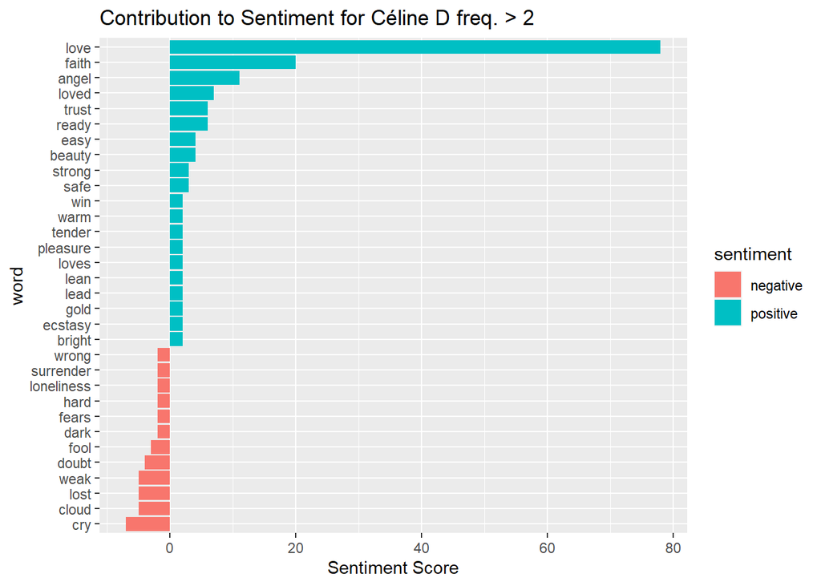

```r
celine_bing <- celine %>%
  inner_join(bing) %>%
  count(word, sentiment, sort = TRUE) %>%
  ungroup()

celine_bing %>%
  filter(n >= 2) %>%
  mutate(n = ifelse(sentiment == "negative", -n , n)) %>%
  mutate(word = reorder(word, n)) %>%
  ggplot(aes(word, n, fill = sentiment)) +
  geom_col() +
  coord_flip() +
  labs(y = "Sentiment Score") +
  ggtitle("Contribution to Sentiment for Céline D freq. > 2")
```

In this case we see that there are more words of at least 2 mentions, and the shift is clearly to the positive sentiment words.

Below I will create a graph that will explicitly show which artist is more positive by the “nrc” lexicon:

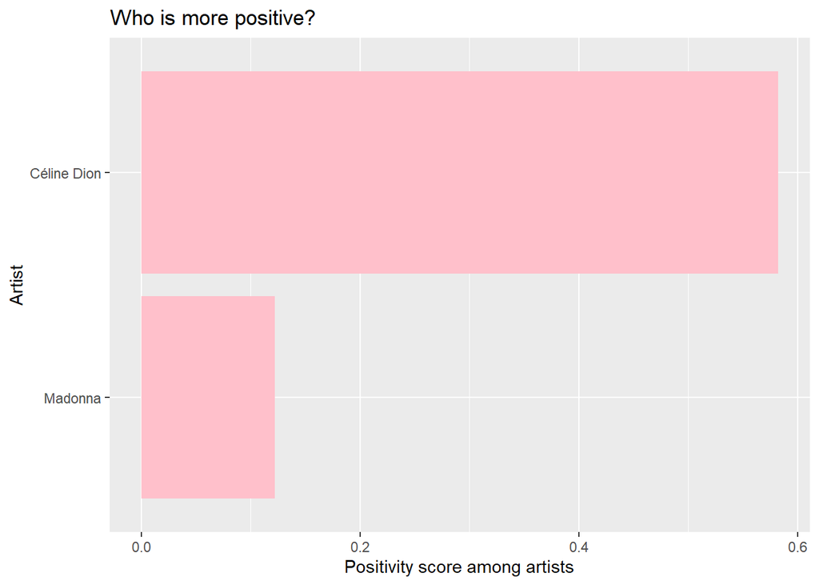

```r
sentiment_count <- df2 %>%
  inner_join(get_sentiments("nrc"), by = "word") %>%
  count(sentiment, artist) %>%
  spread(sentiment, n, fill = 0)


sentiment_count %>%
  mutate(score = (positive - negative) / (positive + negative)) %>%
  mutate(artist = reorder(artist, score)) %>%
  ggplot(aes(artist, score, fill = score > 0)) +
  geom_col(show.legend = FALSE, fill = "pink") +
  coord_flip() +
  labs(x = "Artist",
       y = "Positivity score among artists") +
  ggtitle("Who is more positive?")
```

Here we can clearly see that Céline Dion’s positivity score is much higher.

**Wordclouds**

Let’s create some wordclouds now, to check which are the most commonly used words for these two artists. We have looked into this previously, but it can be seen better visually.

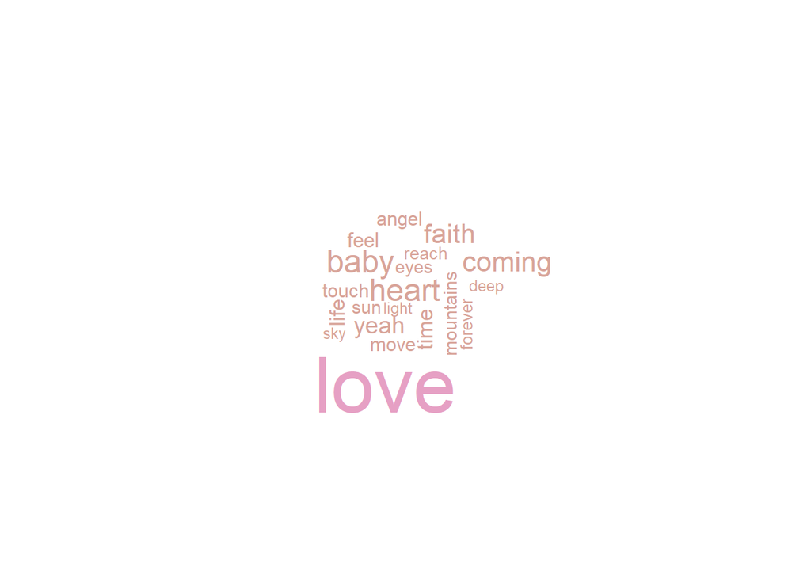

```r
# for Céline Dion

df2 %>%
  filter(artist == "Céline Dion") %>%
  count(word) %>%
  with(wordcloud(word, n, max.words = 20, color = c(wes_palettes$GrandBudapest2[3:1])))
```

Céline Dion is all about love :) But in general, from a bird’s eye view her words, are really a lot more emotional and positive.

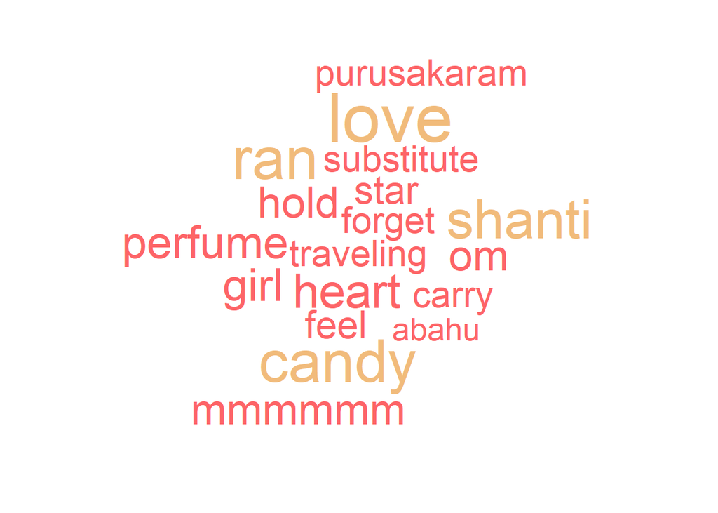

```r
# for Madonna

df2 %>%
  filter(artist == "Madonna") %>%
  count(word) %>%
  with(wordcloud(word, n, max.words = 18, color = c(wes_palettes$GrandBudapest1 [3:1])))
```

As for Madonna? I think it’s energy, movement, being active.

I would refrain from stating anything too harshly but Céline Dion seems to be more of a “thinker” whereas Madonna more of a “do-er” type of person. ( at least in these albums )

Using comparison cloud we can visualize the positive and negative words for both artists.

For Céline Dion

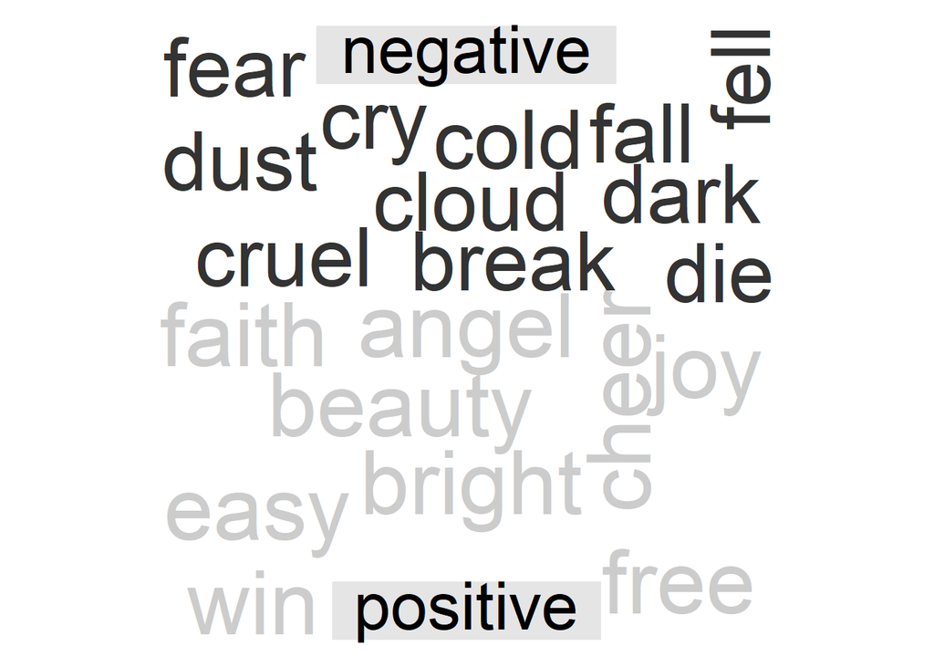

```r
library(reshape2)
celine_bing %>%
  count(word,sentiment, sort= TRUE) %>%
  acast(word ~ sentiment, value.var = "n", fill = 0) %>%
  comparison.cloud(colors= c("gray20", "gray80"),
                   max.words= 120)
```

For Madonna

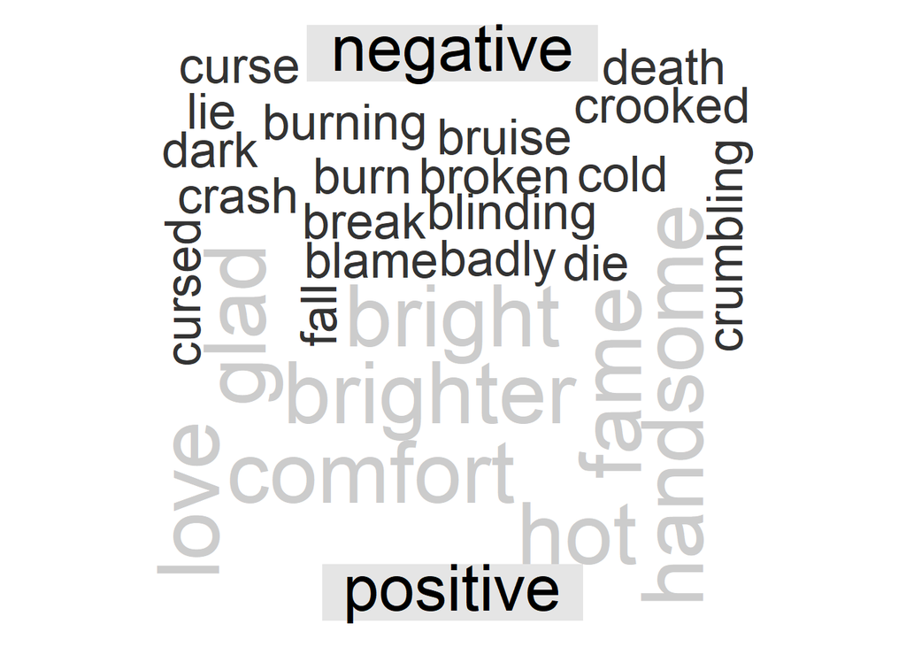

```r
madonna_bing %>%
  count(word,sentiment, sort= TRUE) %>%
  acast(word ~ sentiment, value.var = "n", fill = 0) %>%
  comparison.cloud(colors= c("gray20", "gray80"),
                   max.words= 120)
```

It is of no surprise that Céline Dion has more positive sentiment words listed, than Madonna. Madonna’s comparison cloud is “darker”.

**Tf-idf**

I will now use the stringr library to produce my tf_idf charts. Tf-idf helps to define what are the most important words used by the artists.

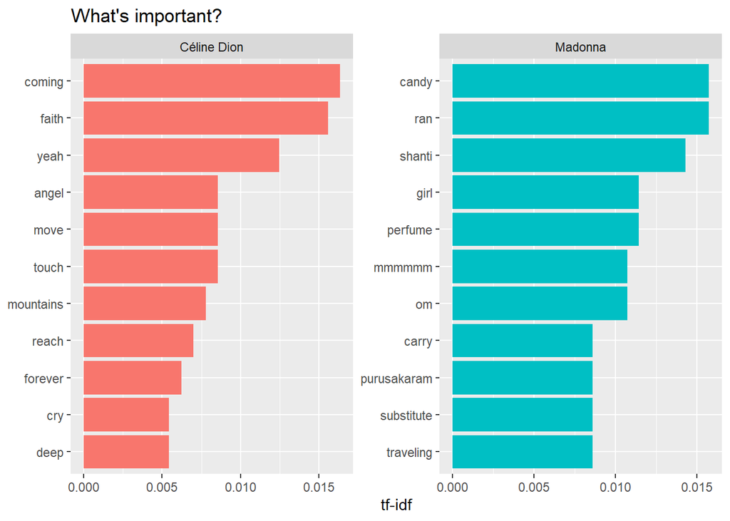

```r
library(stringr)

# create td idf dataframe

df2_tf_idf <- df2 %>%
  count(artist, word) %>%
  filter(!str_detect(word, "\\d+")) %>%
  bind_tf_idf(word, artist, n) %>%
  arrange(-tf_idf)

# create tf-idf chart

df2_tf_idf %>%
  arrange(desc(tf_idf)) %>%
  mutate(word = factor(word, levels = rev(unique(word)))) %>%
  group_by(artist) %>%
  top_n(10) %>%
  ungroup %>%
  ggplot(aes(word, tf_idf, fill = artist)) +
  geom_col(show.legend = FALSE) +
  labs(x = NULL, y = "tf-idf") +
  facet_wrap(~artist, ncol = 2, scales = "free") +
  coord_flip() +
  ggtitle("What's important?")
```

Tf-idf will show how important one words is for the artists. Again we can see that the topics that arise as “important” for Céline Dion are more in the romantic- dreamy field, whereas for Madonna it is much more down to Earth, and less about emotions.

**LDA- Topic Modelling**

Let’s see what different topics lie within the lines of these songs, using Latent Dirichlet Allocation. I will be creating 2 topics, and see what type of words I get in each.

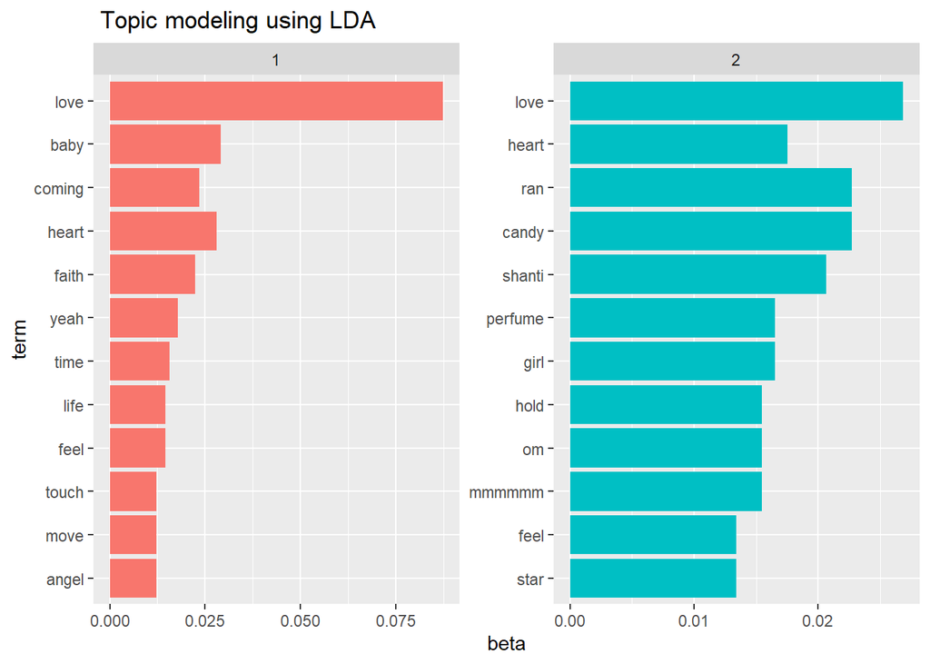

```r
topics <- LDA(cast_dtm(data = df2 %>%
               count(artist, word) %>%
               ungroup(),
             term = word,
             document = artist,
             value = n),
    k = 2, control = list(seed = 42)) %>%
  tidy(matrix = "beta") %>%
  group_by(topic) %>%
  arrange(desc(beta)) %>%
  top_n(12, beta) %>%
  ungroup()
topics %>%
  arrange(topic, -beta) %>%
  mutate(term = reorder(term, beta)) %>%
  ggplot(aes(term, beta, fill = factor(topic))) +
  geom_col(show.legend = FALSE) +
  facet_wrap(~ topic, scales = 'free') +
  coord_flip() +
  ggtitle(" Topic modeling using LDA")
```

Using topic modelling, we are able to make the distinction between Madonna’s and Céline Dion’s “words”. It is clearly visible that Madonna’s words were collected into one of the topics, a topic that to me seems much more down to Earth, versus Céline Dion’s collection of words which are much more about feelings, than activity.

**Conclusion**

My hypothesis, that Céline Dion’s song are more positive than Madonna’s seem to be proved right.This is one of the rare cases when the hypothesis cannot be rejected.

I first looked at the overall frequency of the words available in the two albums. Since the word “love” is one of the most positive words, I first checked which artist uses it more. The word love was used by Céline Dion much more frequently than by Madonna.

Then I looked at the sentiments present in the dataset, also for the individual artists. I also checked which were the most common positive and negative sentiment words, as well as which words contributed most to the various sentiments ( positive or negative). It seemed that Madonna had more words that were contributing to negative sentiments, than Céline Dion.

I used the nrc lexicon to check and visualize who is more positive overall. The answer was clear: Céline Dion.

I also looked at wordclouds to get an overall picture of what words were used most frequenty by the two artists. Comparison cloud helped to visualize the weight of positive and negative words, in the wordcloud.

Using the tf-idf method I was able to identify what words seem to be the most important for the two artists. I was able to derive that for Céline Dion most words defined by the tf-idf method were about emotions, whereas for Madonna they were more down to Earth and active.

To check on my previous findings, I used LDA Topic Modelling to see what the LDA is going to find. I purposely indicated 2 categories, and checked how it divides the words.The pattern that we have seen previously was also visible here, one category was much more active, while the other much more emotional.

Materials used:

[Tidytext book] (https://www.tidytextmining.com/tfidf.html)

[Taylor Swift song analysis] (https://github.com/simranvatsa/tayloR/blob/master/tayloR_final.R)

[Wordcloud Fundamentals] (http://www.sthda.com/english/wiki/text-mining-and-word-cloud-fundamentals-in-r-5-simple-steps-you-should-know)

[Text Analysis from former student] (https://github.com/thegrigorian/TextAnalysisWithGutenberg)

[Song Analysis from former student ] (https://github.com/BenceToth/nlp_songlyrics/blob/master/DS4_final-assignment_Bence-L-Toth_166504.rmd)

[Genius package for R] (https://github.com/JosiahParry/genius)